# R Seminar Part 3: Multivariate Data

Dr Ben Dickins

16/12/2020

## Introduction

3. Crown 2020 copyright Defra via uk-air.defra.gov.uk, licenced under the [Open Government Licence](http://www.nationalarchives.gov.uk/doc/open-government-licence/version/2/) (OGL).

## Step 1: Data

The next file we will look at is “pollution.csv”.

### Step 2: Setting the working directory

set from previous…

### Step 3: Load Library

In addition to core tidyverse we will need to load a package called lubridate:

```r
library(tidyverse)
library(lubridate)
```

## Let’s Get Going!

### Step 1: Loading Data

Let’s load it into R using a tidyverse function:

```r
pollution <- read_csv("pollution.csv", col_types = "cTdddc")
```

### Step 2: Look at data

```r
#View(pollution)
#head(pollution)
#glimpse(pollution)

pollution$NO2
```

[output not shown]

[output cut: 5542 more lines]

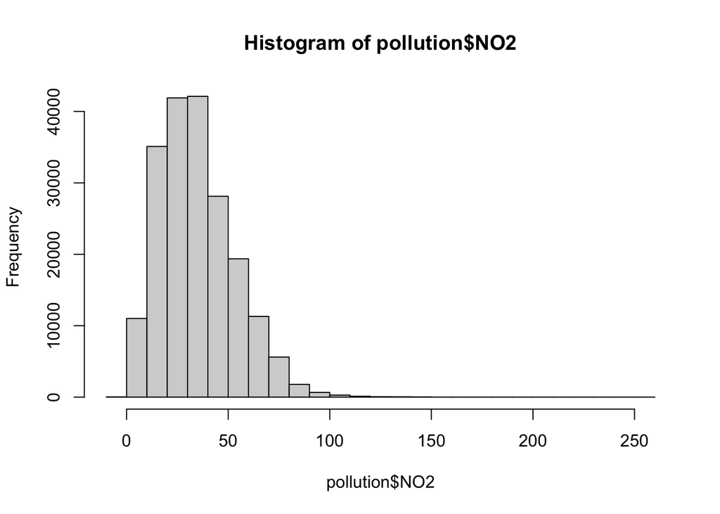

```r
hist(pollution$NO2)
```

### Step 3: Summary Data

Let’s take the mean of one variable:

```r
mean(pollution$NO2)
```

```
## [1] NA
```

Bad result - why?

Because of NA data - this is a common problem and many functions have options to deal with it:

```r
mean(pollution$NO2, na.rm = TRUE)
```

```
## [1] 34.94711
```

```r
summary(pollution$NO2)
```

```
##    Min. 1st Qu.  Median    Mean 3rd Qu.    Max.    NA's
##  -0.006  21.000  32.000  34.947  46.146 256.000   14287
```

The summary() function can also be applied to the whole tibble:

```r
summary(pollution)
```

```
##      code                date                          NO2
##  Length:211848      Min.   :1996-09-11 00:00:00   Min.   : -0.006
##  Class :character   1st Qu.:2002-09-26 17:45:00   1st Qu.: 21.000
##  Mode  :character   Median :2008-10-11 11:30:00   Median : 32.000
##                     Mean   :2008-10-11 11:30:00   Mean   : 34.947
##                     3rd Qu.:2014-10-27 05:15:00   3rd Qu.: 46.146
##                     Max.   :2020-11-10 23:00:00   Max.   :256.000
##                                                   NA's   :14287
##     NOXasNO2           PM2.5            site
##  Min.   :   0.00   Min.   : -4.30   Length:211848
##  1st Qu.:  28.76   1st Qu.:  5.40   Class :character
##  Median :  46.00   Median :  8.90   Mode  :character
##  Mean   :  62.97   Mean   : 11.94
##  3rd Qu.:  76.00   3rd Qu.: 14.70
##  Max.   :1518.00   Max.   :362.00
##  NA's   :14287     NA's   :115849
```

### Step 4: Graphs

Histogram:

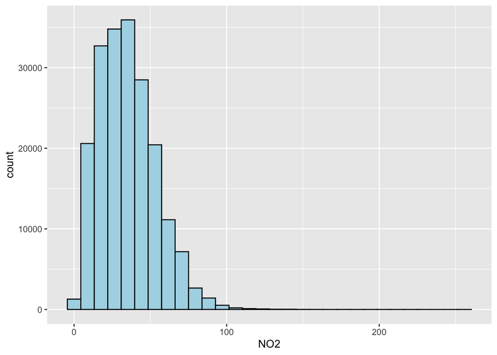

```r
ggplot(pollution, aes(x=NO2)) + geom_histogram(colour = "black", fill = "lightblue")
```

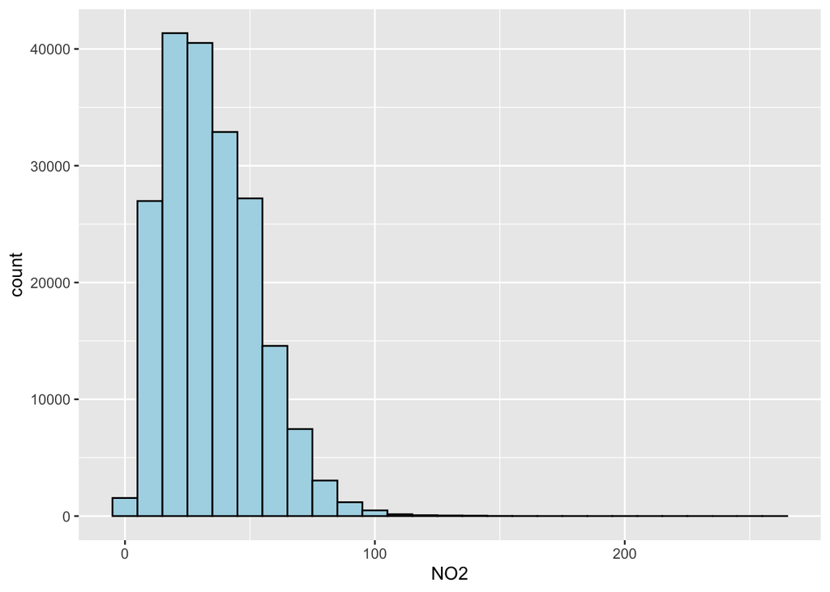

```r
# controlling bin width
ggplot(pollution, aes(x=NO2)) + geom_histogram(colour = "black", fill = "lightblue", binwidth = 10)
```

Two-variable scatter plot:

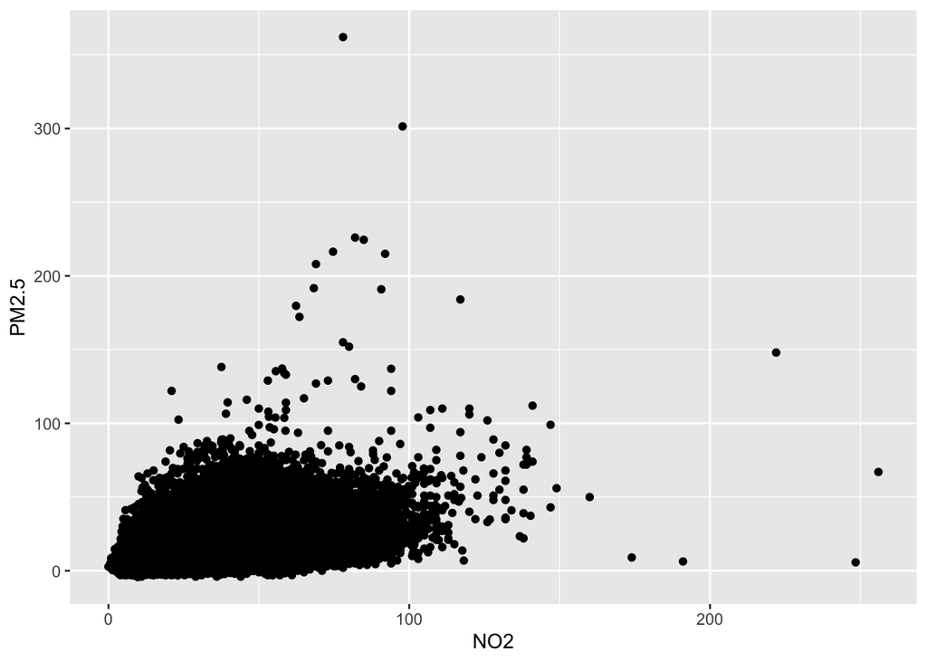

```r
ggplot(pollution, aes(x=NO2, y=PM2.5)) + geom_point()
```

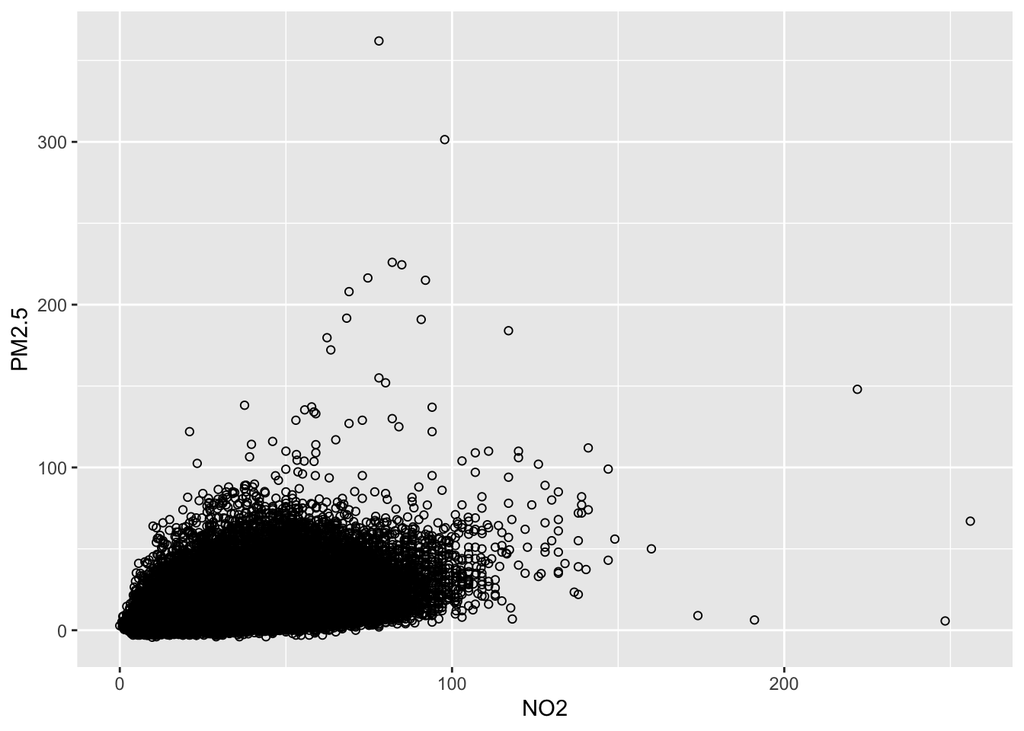

```r
# changing the shape
ggplot(pollution, aes(x=NO2, y=PM2.5)) + geom_point(shape=21)
```

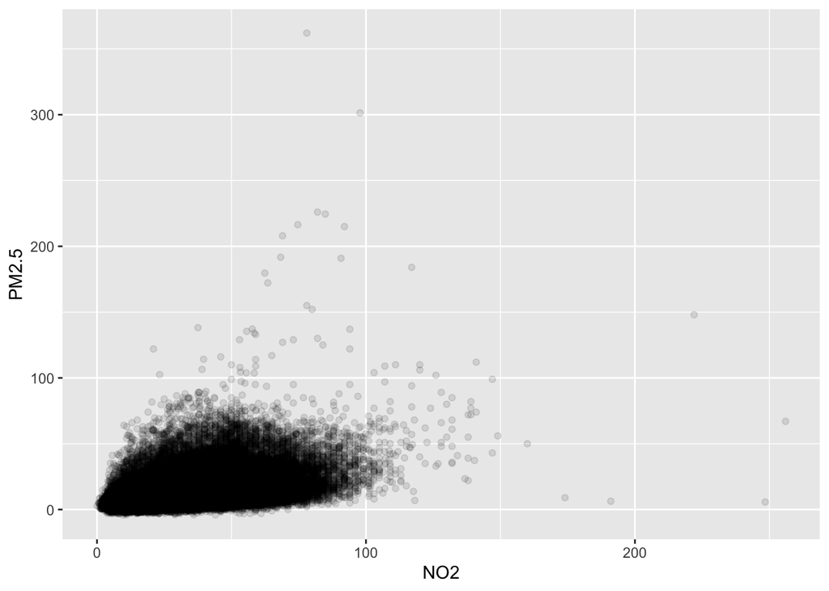

```r
# adding transparency (so you can see density of points)
ggplot(pollution, aes(x=NO2, y=PM2.5)) + geom_point(alpha=0.1)
```

Adding a linear regression line:

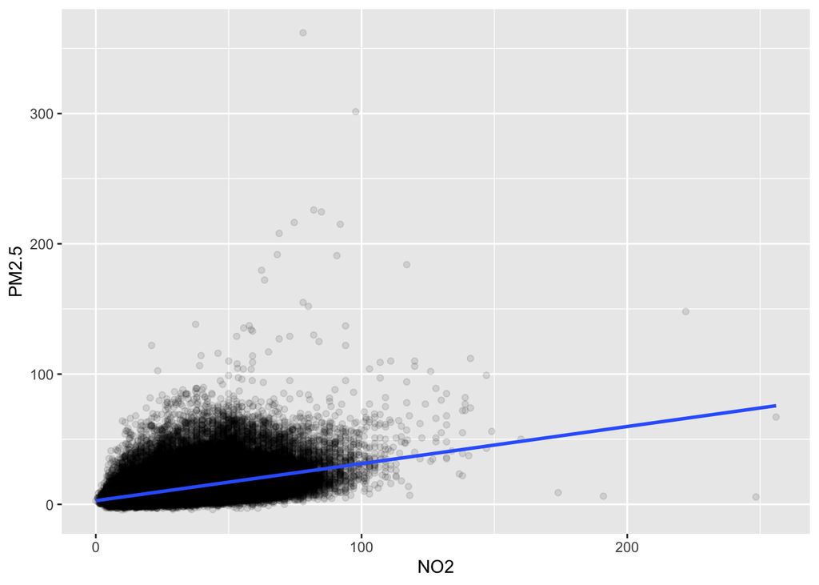

```r
ggplot(pollution, aes(x=NO2, y=PM2.5)) + geom_point(alpha=.1) + stat_smooth(method=lm)
```

Adding a new variable:

```r
pollution <- pollution %>% mutate(Year = year(date))
```

Plotting new plots for each year:

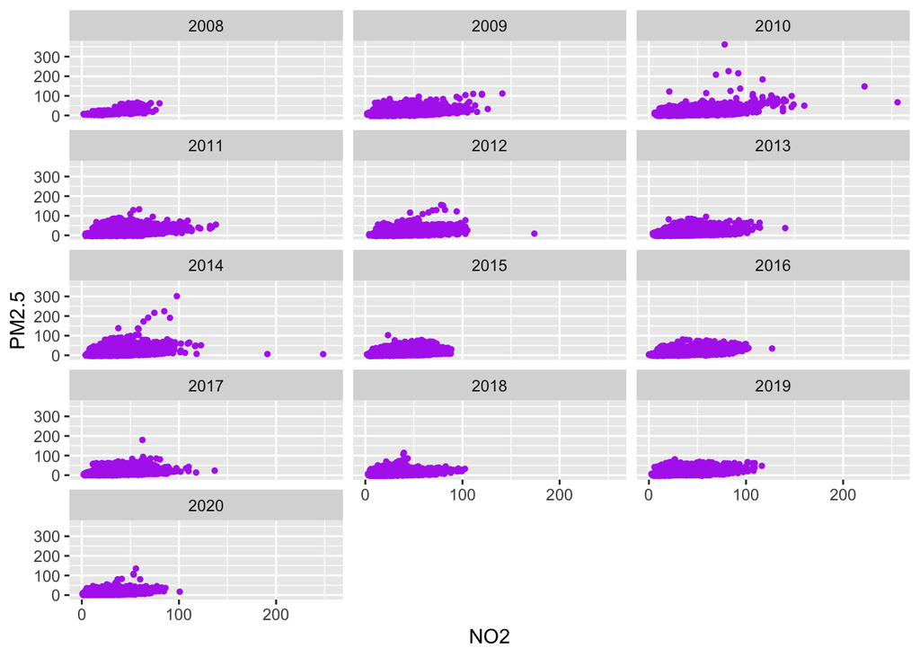

```r
pollution %>% na.omit() %>% ggplot(aes(x=NO2, y=PM2.5)) + geom_point(size=1, colour="darkorchid2") + facet_wrap(~ Year, ncol=3)
```

Boxplots!

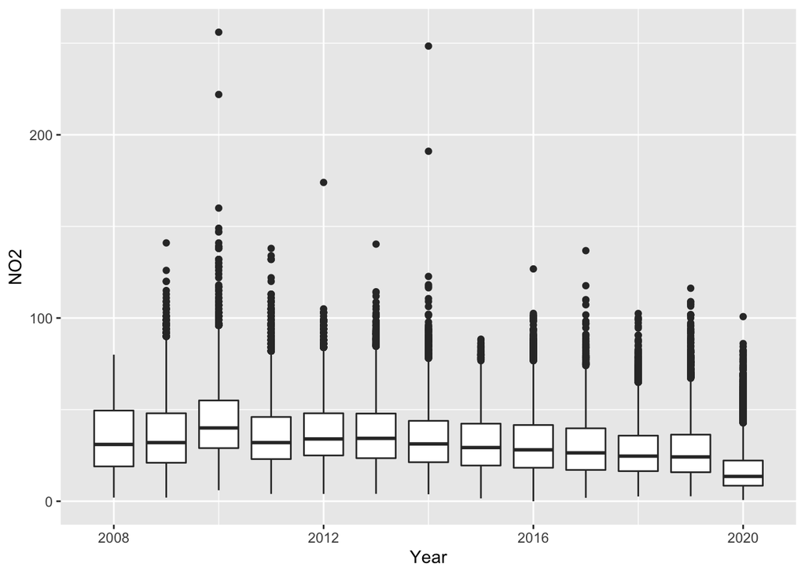

```r
pollution %>% na.omit() %>% ggplot(aes(x=Year, y=NO2)) + geom_boxplot(aes(group=Year))
```

### Step 5: Bit of a dump I’m afraid - too little time to organise!

Dataset built into dplyr (tidyverse):

```r
storms
```

```
## # A tibble: 10,010 x 13
##    name   year month   day  hour   lat  long status category  wind pressure
##    <chr> <dbl> <dbl> <int> <dbl> <dbl> <dbl> <chr>  <ord>    <int>    <int>
##  1 Amy    1975     6    27     0  27.5 -79   tropi… -1          25     1013
##  2 Amy    1975     6    27     6  28.5 -79   tropi… -1          25     1013
##  3 Amy    1975     6    27    12  29.5 -79   tropi… -1          25     1013
##  4 Amy    1975     6    27    18  30.5 -79   tropi… -1          25     1013
##  5 Amy    1975     6    28     0  31.5 -78.8 tropi… -1          25     1012
##  6 Amy    1975     6    28     6  32.4 -78.7 tropi… -1          25     1012
##  7 Amy    1975     6    28    12  33.3 -78   tropi… -1          25     1011
##  8 Amy    1975     6    28    18  34   -77   tropi… -1          30     1006
##  9 Amy    1975     6    29     0  34.4 -75.8 tropi… 0           35     1004
## 10 Amy    1975     6    29     6  34   -74.8 tropi… 0           40     1002
## # … with 10,000 more rows, and 2 more variables: ts_diameter <dbl>,
## #   hu_diameter <dbl>
```

```r
?storms
summary(storms)
```

```
##      name                year          month             day
##  Length:10010       Min.   :1975   Min.   : 1.000   Min.   : 1.00
##  Class :character   1st Qu.:1990   1st Qu.: 8.000   1st Qu.: 8.00
##  Mode  :character   Median :1999   Median : 9.000   Median :16.00
##                     Mean   :1998   Mean   : 8.779   Mean   :15.86
##                     3rd Qu.:2006   3rd Qu.: 9.000   3rd Qu.:24.00
##                     Max.   :2015   Max.   :12.000   Max.   :31.00
##
##       hour             lat             long            status
##  Min.   : 0.000   Min.   : 7.20   Min.   :-109.30   Length:10010
##  1st Qu.: 6.000   1st Qu.:17.50   1st Qu.: -80.70   Class :character
##  Median :12.000   Median :24.40   Median : -64.50   Mode  :character
##  Mean   : 9.114   Mean   :24.76   Mean   : -64.23
##  3rd Qu.:18.000   3rd Qu.:31.30   3rd Qu.: -48.60
##  Max.   :23.000   Max.   :51.90   Max.   :  -6.00
##
##  category       wind           pressure       ts_diameter       hu_diameter
##  -1:2545   Min.   : 10.00   Min.   : 882.0   Min.   :   0.00   Min.   :  0.00
##  0 :4373   1st Qu.: 30.00   1st Qu.: 985.0   1st Qu.:  69.05   1st Qu.:  0.00
##  1 :1685   Median : 45.00   Median : 999.0   Median : 138.09   Median :  0.00
##  2 : 628   Mean   : 53.49   Mean   : 992.1   Mean   : 166.76   Mean   : 21.41
##  3 : 363   3rd Qu.: 65.00   3rd Qu.:1006.0   3rd Qu.: 241.66   3rd Qu.: 28.77
##  4 : 348   Max.   :160.00   Max.   :1022.0   Max.   :1001.18   Max.   :345.23
##  5 :  68                                     NA's   :6528      NA's   :6528
```

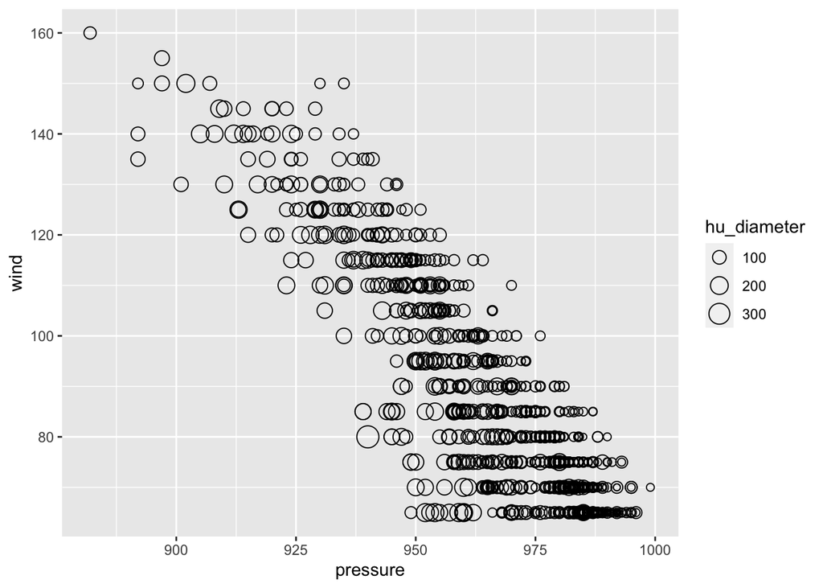

```r
#point size with another variable:
storms %>% filter(status == "hurricane") %>% na.omit() %>% ggplot(aes(x=pressure, y=wind, size=hu_diameter)) + geom_point(shape=21)
```

```r
# see how it sensibly adds a legend?
```

Make a new plot but don’t plot it yet:

```r
stormplot <- storms %>% filter(status == "hurricane") %>% na.omit() %>% ggplot(aes(x=pressure, y=wind)) + geom_point()
```

Now plot it with a linear line:

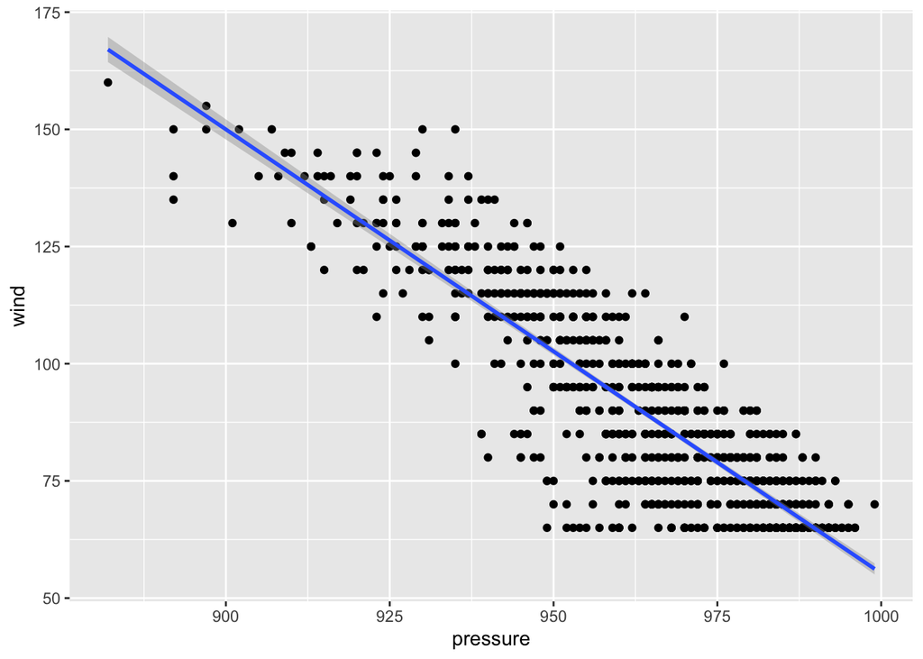

```r
stormplot + stat_smooth(method=lm)
```

With a LOESS method:

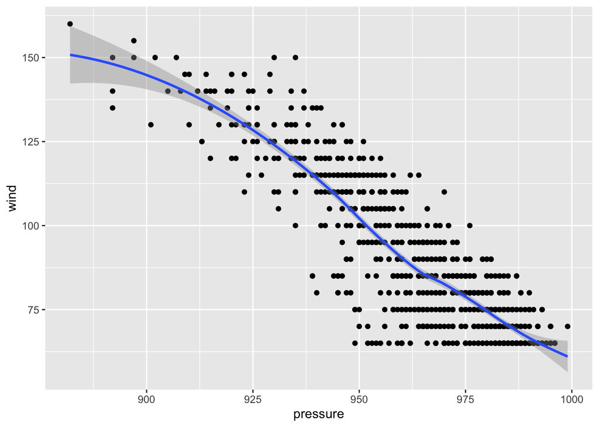

```r
stormplot + stat_smooth(method=loess)
```

A little bit of linear modelling:

```r
model = lm(wind ~ pressure, storms)
model
```

```
##
## Call:
## lm(formula = wind ~ pressure, data = storms)
##
## Coefficients:
## (Intercept)     pressure
##    1309.124       -1.266
```

```r
summary(model)
```

```
##
## Call:
## lm(formula = wind ~ pressure, data = storms)
##
## Residuals:
##     Min      1Q  Median      3Q     Max
## -45.229  -4.874   0.250   5.375  40.126
##
## Coefficients:
##               Estimate Std. Error t value Pr(>|t|)
## (Intercept)  1.309e+03  4.462e+00   293.4   <2e-16 ***
## pressure    -1.266e+00  4.497e-03  -281.5   <2e-16 ***
## ---
## Signif. codes:  0 '***' 0.001 '**' 0.01 '*' 0.05 '.' 0.1 ' ' 1
##
## Residual standard error: 8.78 on 10008 degrees of freedom
## Multiple R-squared:  0.8878, Adjusted R-squared:  0.8878
## F-statistic: 7.922e+04 on 1 and 10008 DF,  p-value: < 2.2e-16
```

Adding categorical to plot:

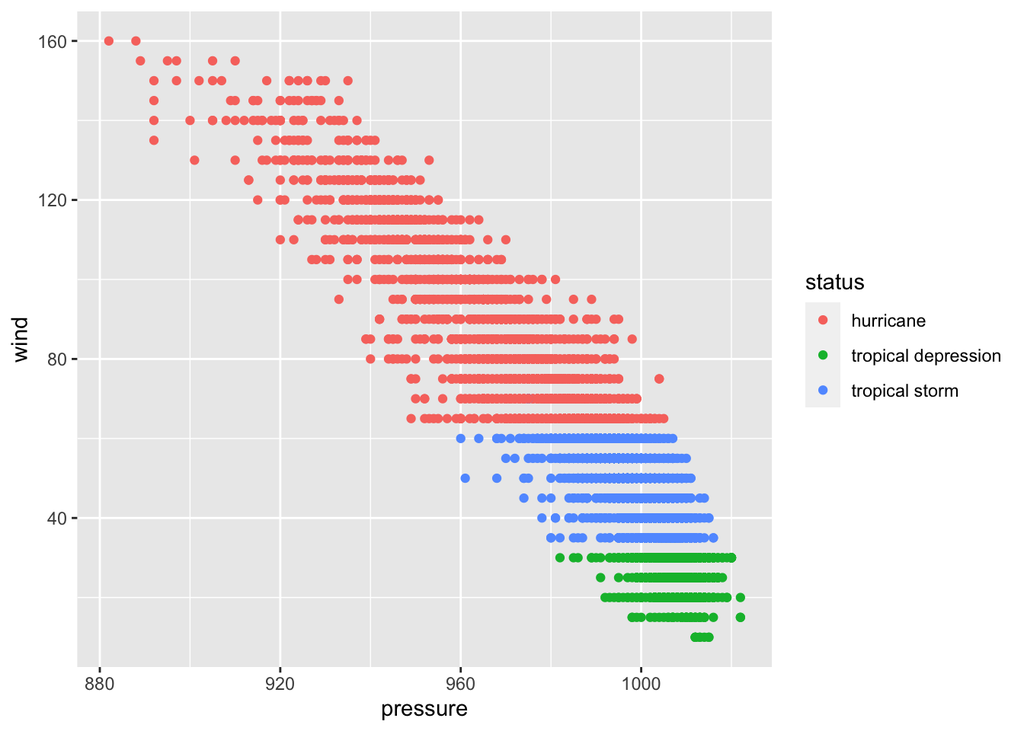

```r
storms %>% ggplot(aes(x=pressure, y=wind, colour=status)) + geom_point()
```

With categorical and facet wrap:

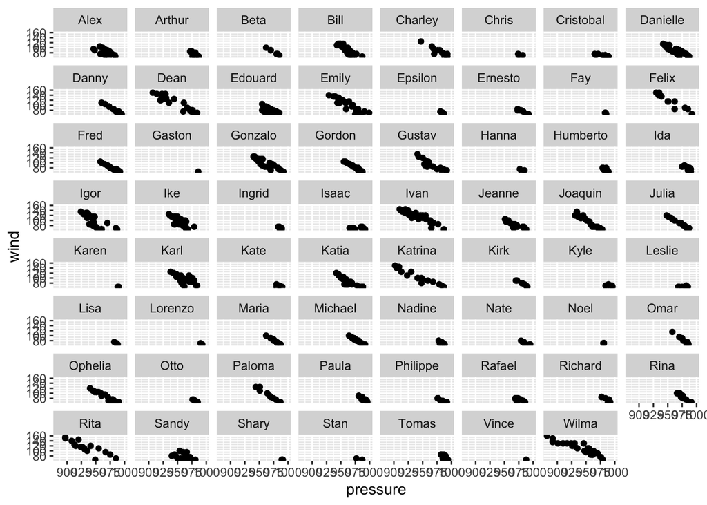

```r
stormplot + facet_wrap(~name)
```

Boxplot:

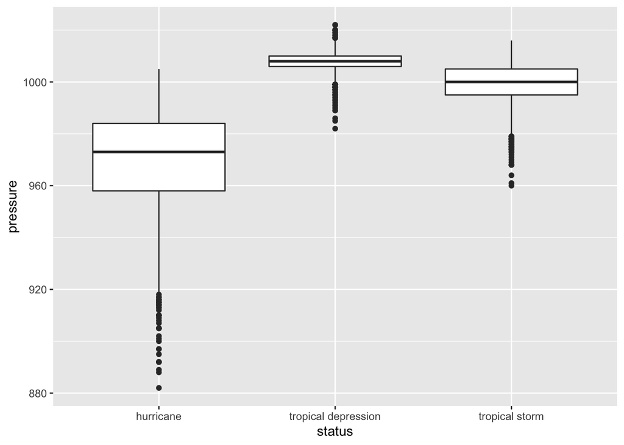

```r
storms %>% ggplot(aes(x=status, y=pressure, group=status)) + geom_boxplot()
```

## Tips dataset - direct load from web

First allow me to acknowledge data source: https://github.com/mwaskom/seaborn-data

```r
tips <- read_csv("https://raw.githubusercontent.com/mwaskom/seaborn-data/master/tips.csv")
```

Univariate plots of various kinds:

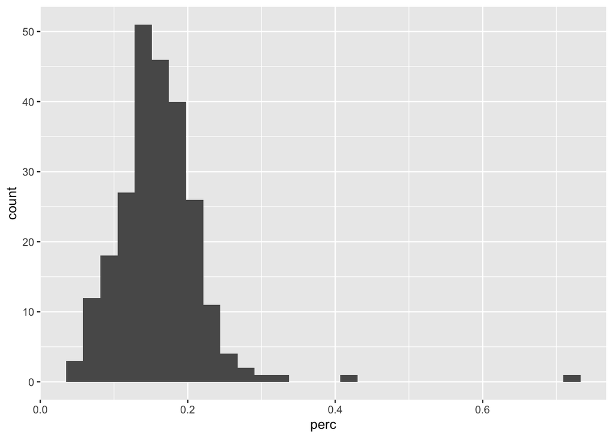

```r
tips %>% mutate(perc = tip/total_bill) %>% ggplot(aes(x=perc)) + geom_histogram()
```

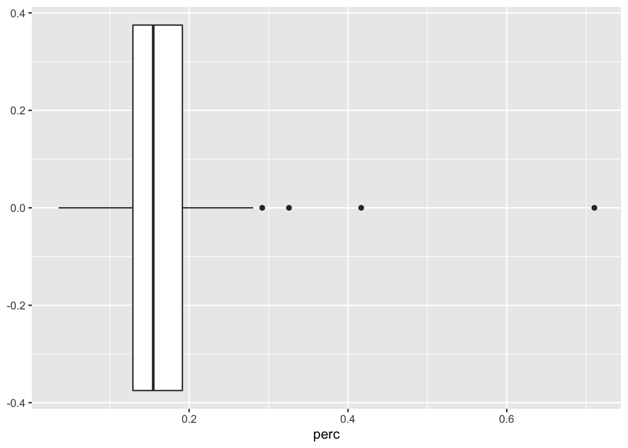

```r
tips %>% mutate(perc = tip/total_bill) %>% ggplot(aes(x=perc)) + geom_boxplot()
```

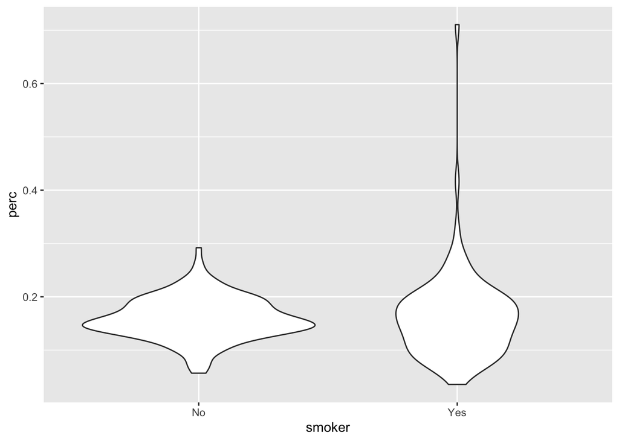

```r
tips %>% mutate(perc = tip/total_bill) %>% ggplot(aes(x=smoker, y=perc)) + geom_violin()
```

Separating by a categorical variable:

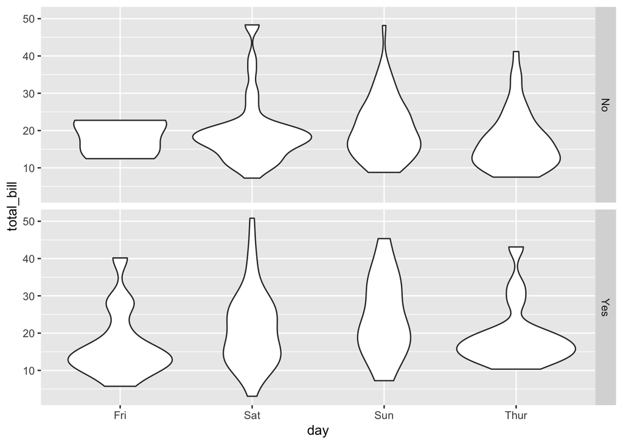

```r
ggplot(tips, aes(x=day, y=total_bill)) + geom_violin() + facet_grid(smoker~.)
```

Very nice apporach to kernel density (violin) plots from recipe 6.9 in https://r-graphics.org:

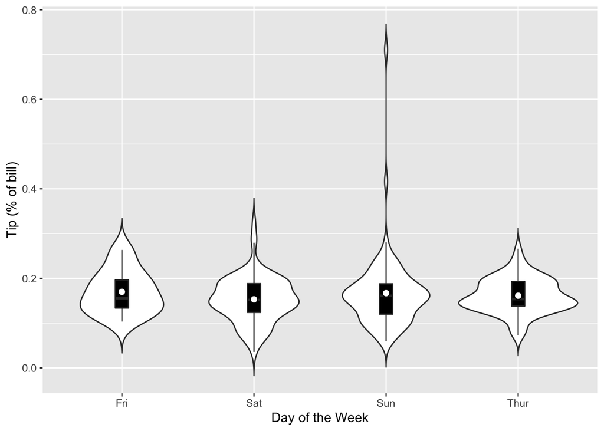

```r
plot <- tips %>% mutate(perc = tip/total_bill) %>% ggplot(aes(x=day, y=perc)) + geom_violin(trim = FALSE)

plot + geom_boxplot(width=.1, fill="black", outlier.colour=NA) + stat_summary(fun=mean, geom="point", fill="white", shape=21, size=2.5) + labs(x="Day of the Week", y="Tip (% of bill)")
```